# Efecto Airbnb en Donostia

Este informe se ha generado automáticamente con R a partir del [script de Rmarkdown](https://github.com/montera34/airbnbeuskadi/tree/master/analisis/montera34/airbnb-informe-ciudad.Rmd) disponible en el [repositorio airbnbeuskadi](https://github.com/montera34/airbnbeuskadi/).

## Datos

- InsideAirbnb.com/euskadi
- Fecha scraping: 2017-03-24

## Resumen

En **Donostia** hay publicados 1219 anuncios de Airbnb, que tienen capacidad para 4553 personas (accommodates).

De esos anuncios 160 han sido dados de alta en el Registro de Empresas Turísticas del Gobierno Vasco (lo que supone un 13.1 % del municipio).

Estos anuncios (listings, en la terminología de Airbnb) han sido publicados por 696 anfitriones.

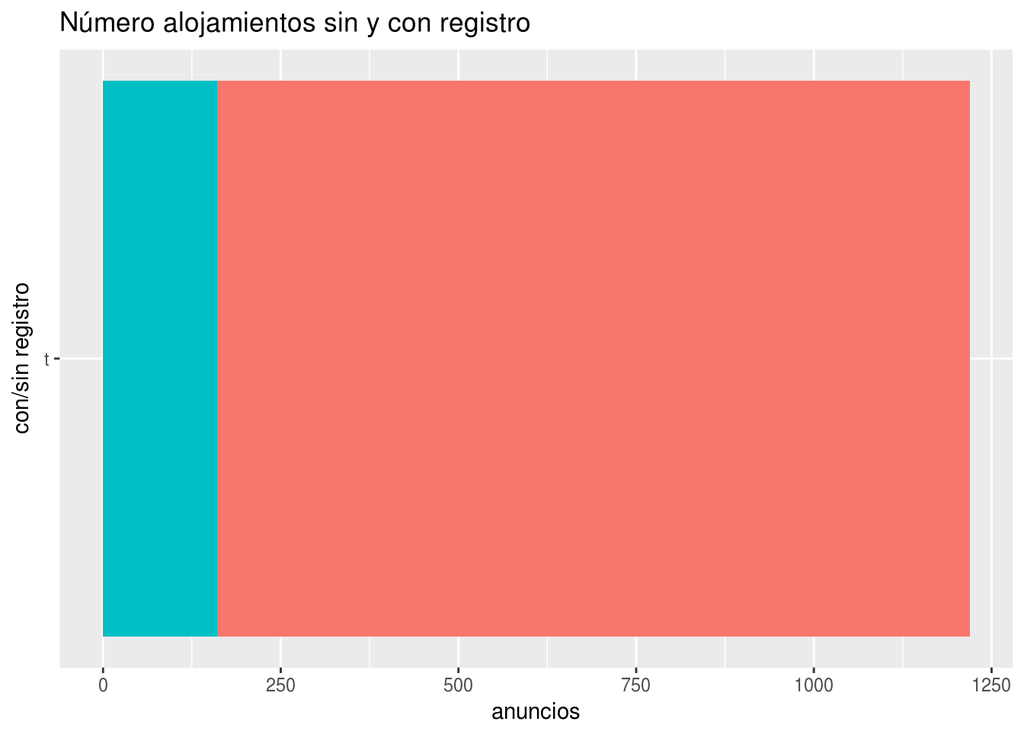

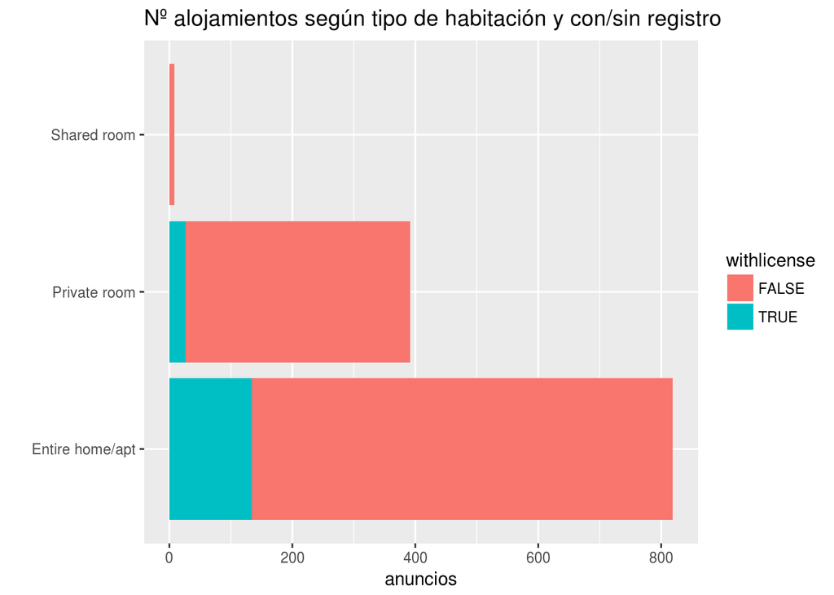

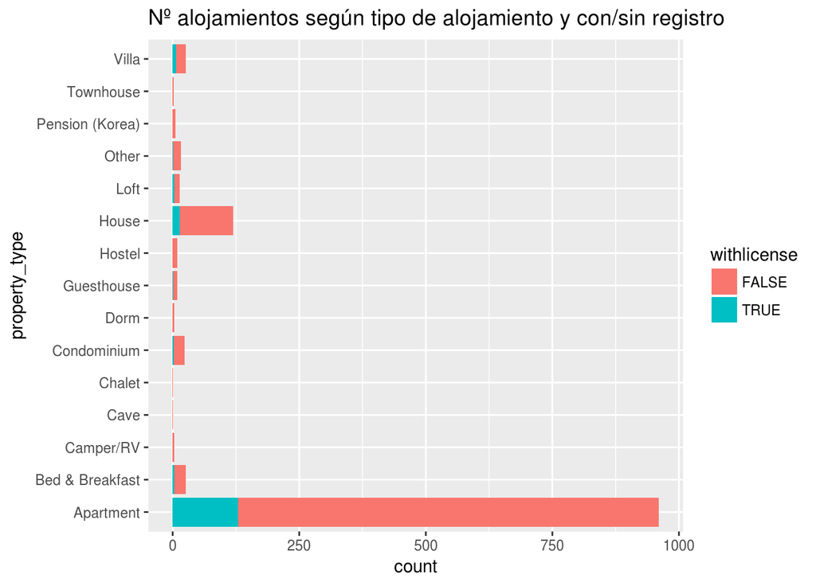

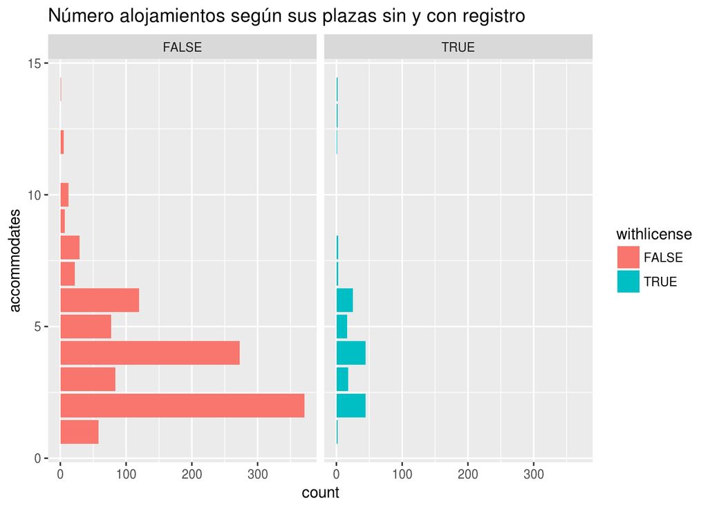

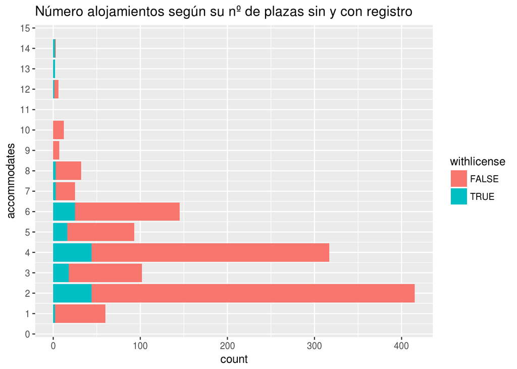

## Anfitriones en Airbnb

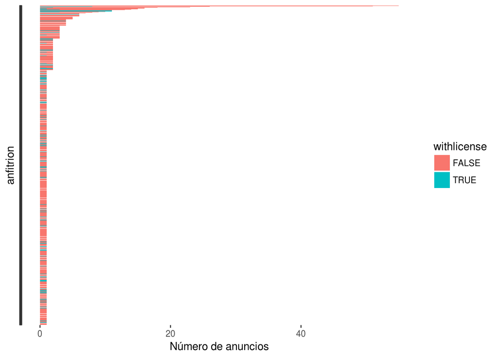

### Los anfitriones con más alojamientos

Los 20 anfitriones con más alojamientos (id)

| host_id | alojamientos |
| --- | --- |
| 15707672 | 55 |
| 98419892 | 51 |
| 3952766 | 26 |
| 5254782 | 23 |
| 4614604 | 18 |
| 790667 | 16 |
| 12954077 | 16 |
| 13367653 | 15 |
| 6598471 | 14 |
| 25039584 | 13 |
| 18192487 | 11 |
| 98189424 | 11 |
| 102583389 | 11 |
| 149691 | 10 |
| 50920106 | 9 |
| 2470030 | 8 |
| 73815563 | 7 |
| 2035832 | 6 |
| 2625306 | 6 |
| 5173315 | 6 |

### Los anfitriones con más plazas

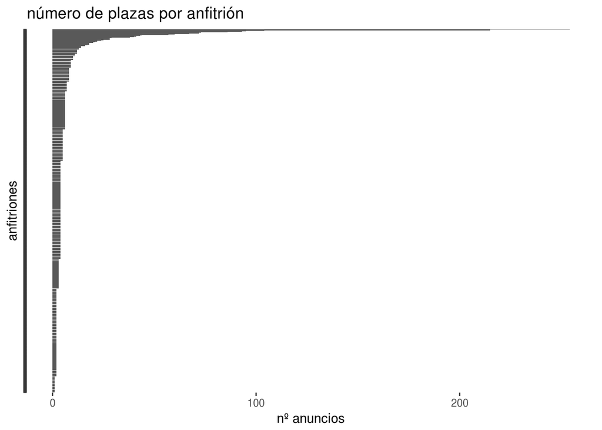

Los 10 primeros anfitriones (1.4% del total de anfitriones) con más plazas tienen 1119 plazas disponibles (que son el 24.6% del total de plazas).

Los 20 primeros anfitriones (2.9% del total de anfitriones) con más plazas tienen 1495 plazas disponibles (que son el 32.8% del total de plazas).

Los 50 primeros anfitriones (7.2% del total de anfitriones) con más plazas tienen 1958 plazas disponibles (que son el 43.0% del total de plazas).

Los 100 primeros anfitriones (14.4% del total de anfitriones) con más plazas tienen 2392 plazas disponibles (que son el 52.5% del total de plazas).

Los 30 anfitriones (host_id) con más alojamientos tienen n plazas (accomodates)

| host_id | plazas |
| --- | --- |
| 98419892 | 254 |
| 15707672 | 215 |
| 4614604 | 104 |
| 5254782 | 95 |
| 3952766 | 93 |
| 12954077 | 86 |
| 6598471 | 73 |
| 25039584 | 72 |
| 13367653 | 67 |
| 102583389 | 60 |
| 98189424 | 57 |
| 2470030 | 44 |
| 50920106 | 43 |
| 18192487 | 41 |
| 790667 | 40 |
| 13725999 | 38 |
| 149691 | 29 |
| 10650761 | 28 |
| 63853491 | 28 |
| 109977260 | 28 |
| 2035832 | 25 |
| 1589633 | 24 |
| 5172999 | 22 |
| 5173315 | 22 |
| 37985139 | 21 |
| 49473712 | 20 |
| 26474511 | 18 |
| 38990075 | 18 |
| 71316977 | 18 |
| 85246818 | 18 |

### Número de reviews por cada alojamiento

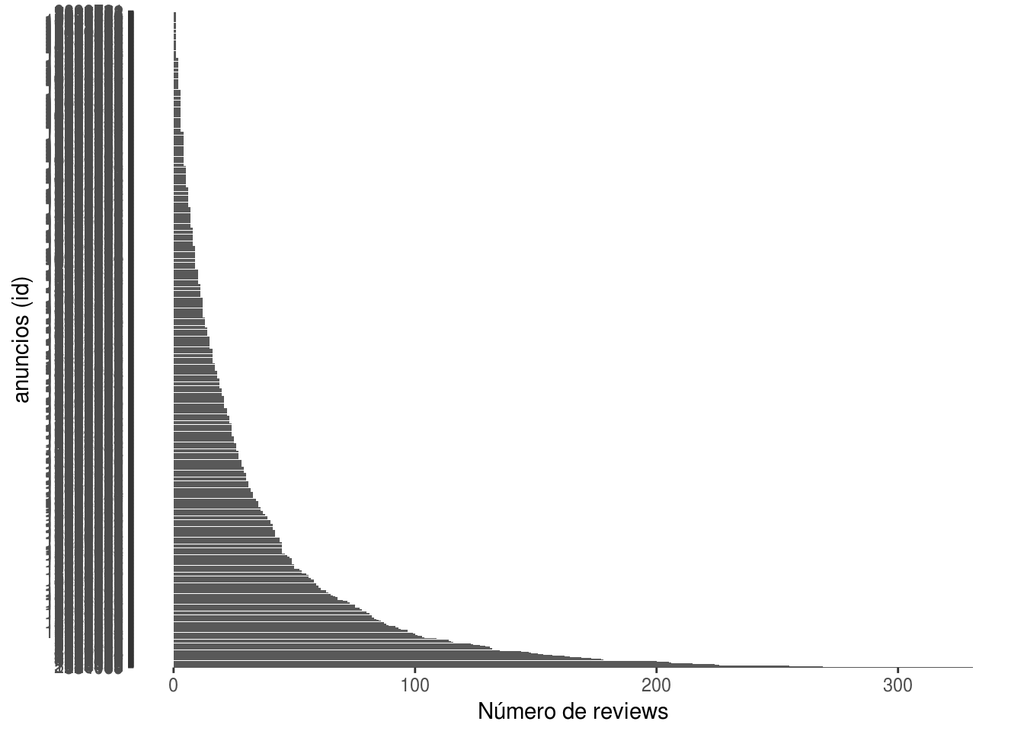

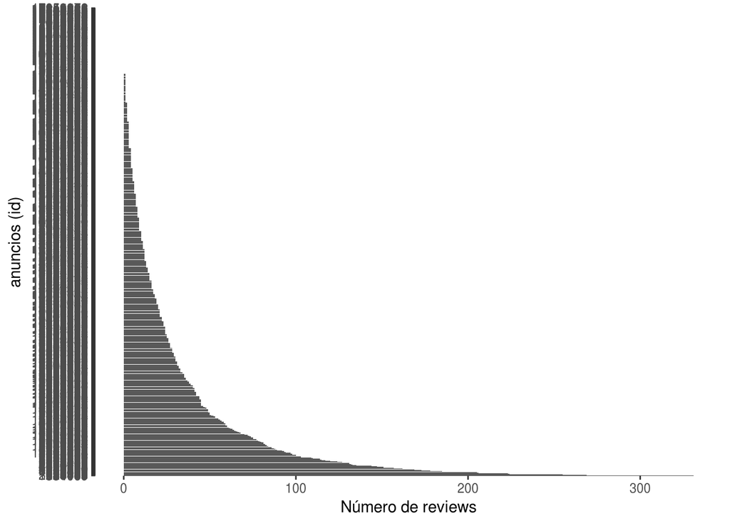

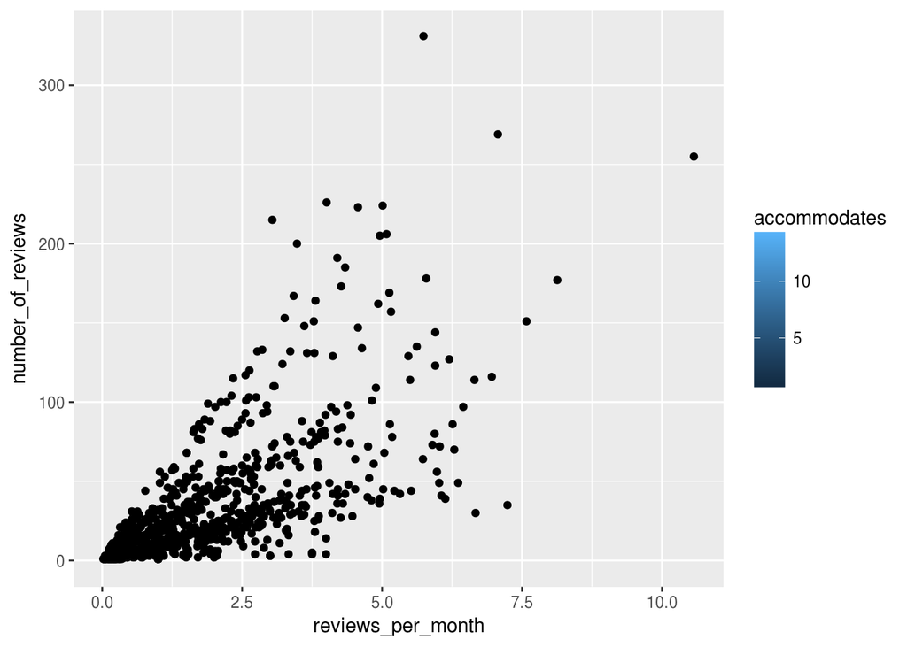

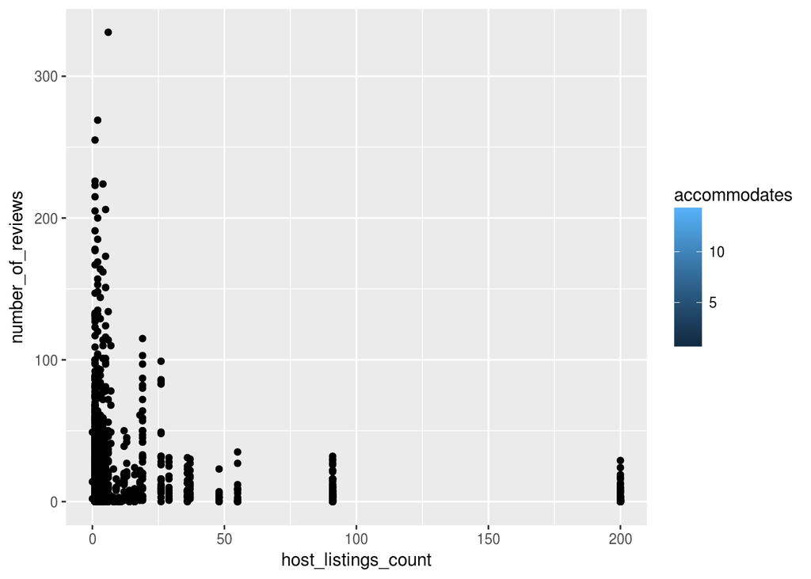

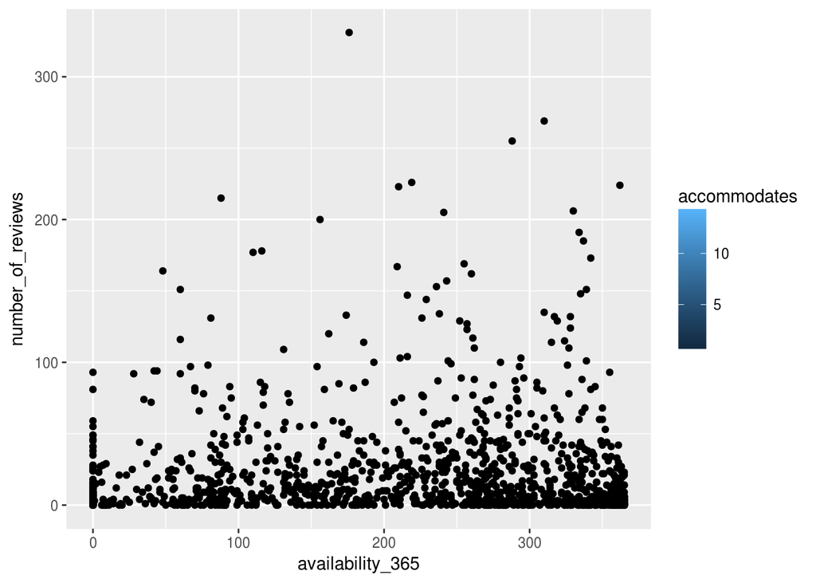

### Precio por noche

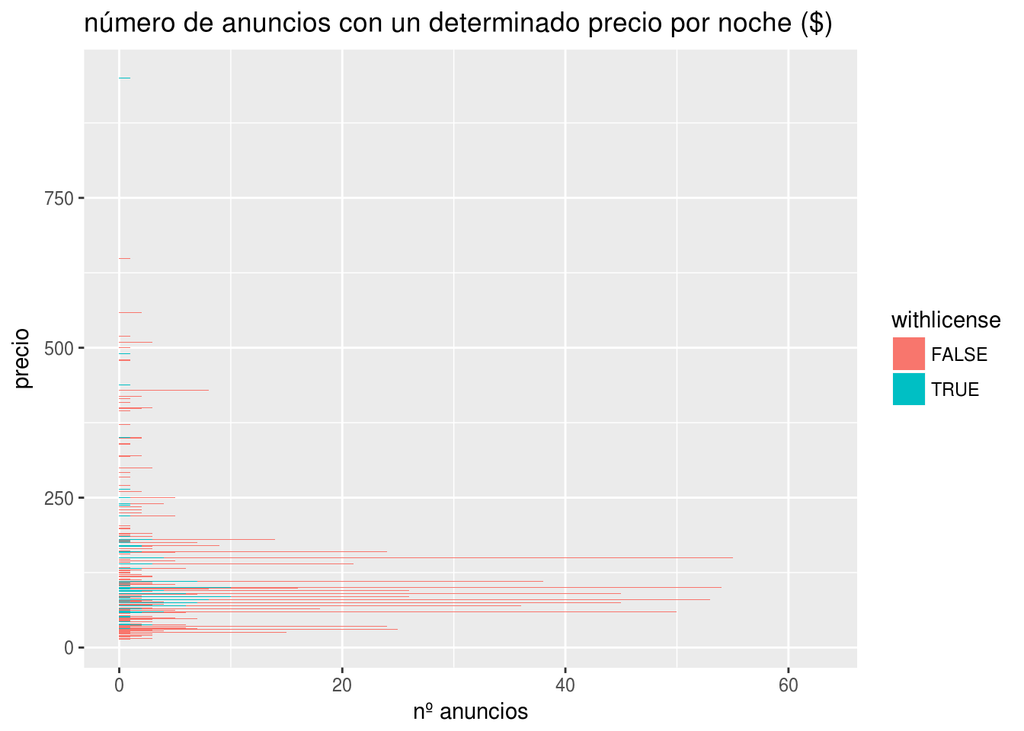

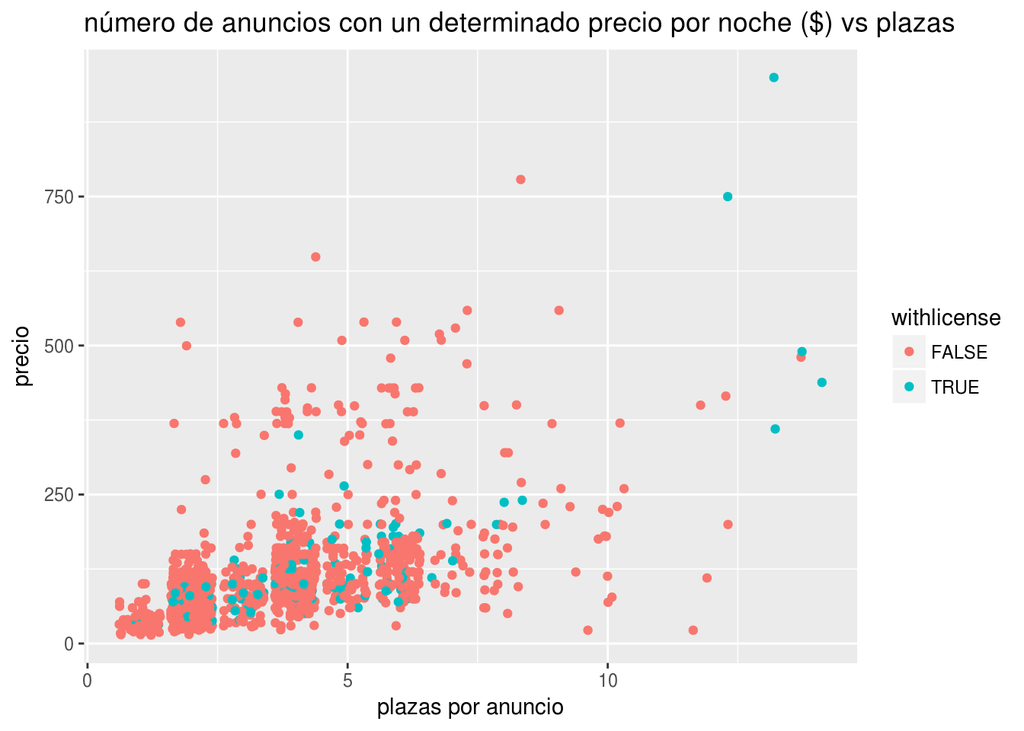

## Otros

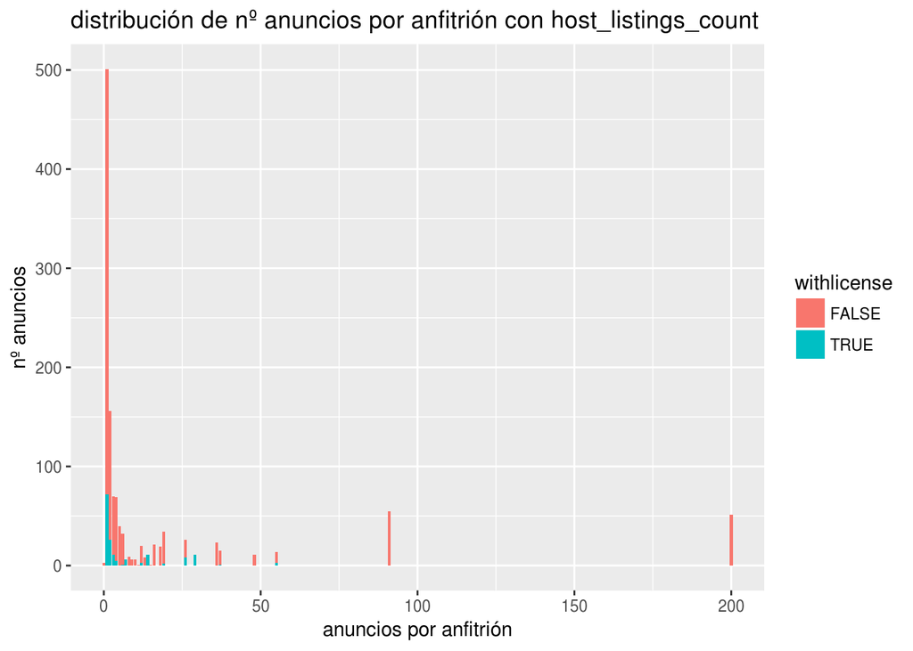

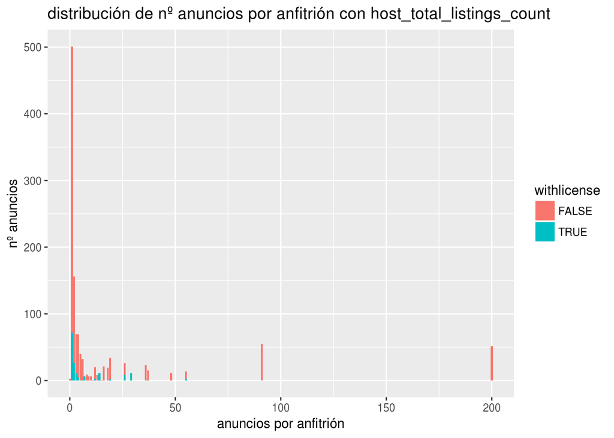

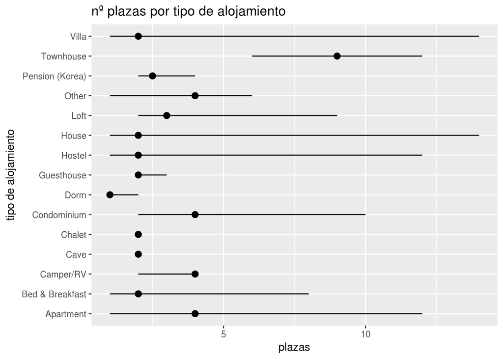

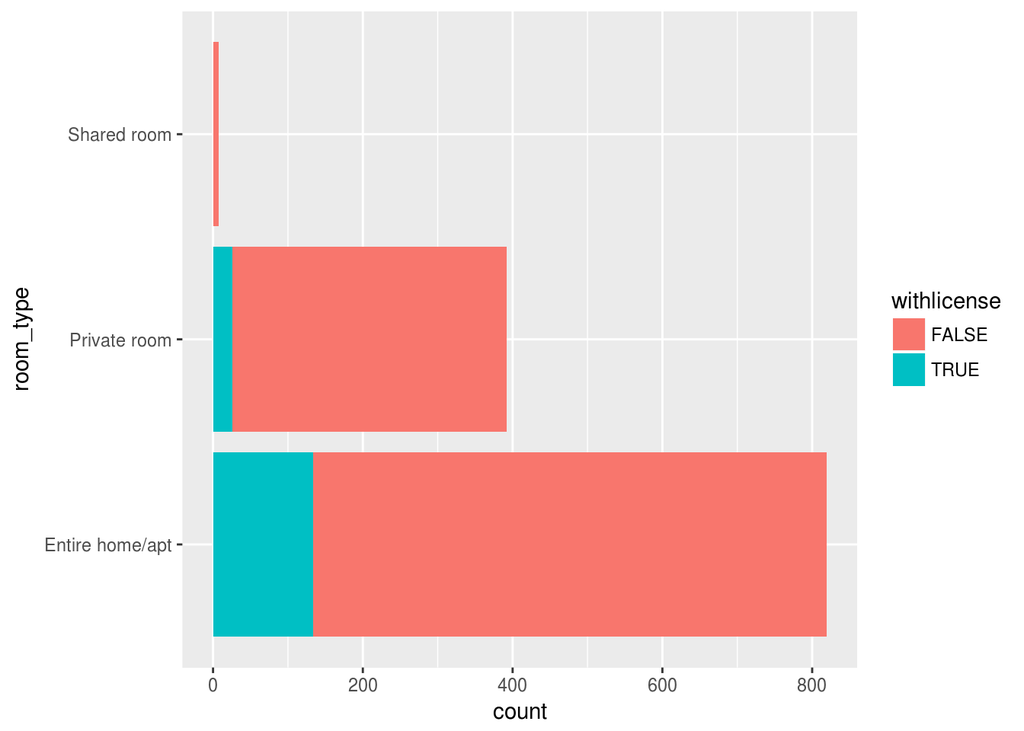

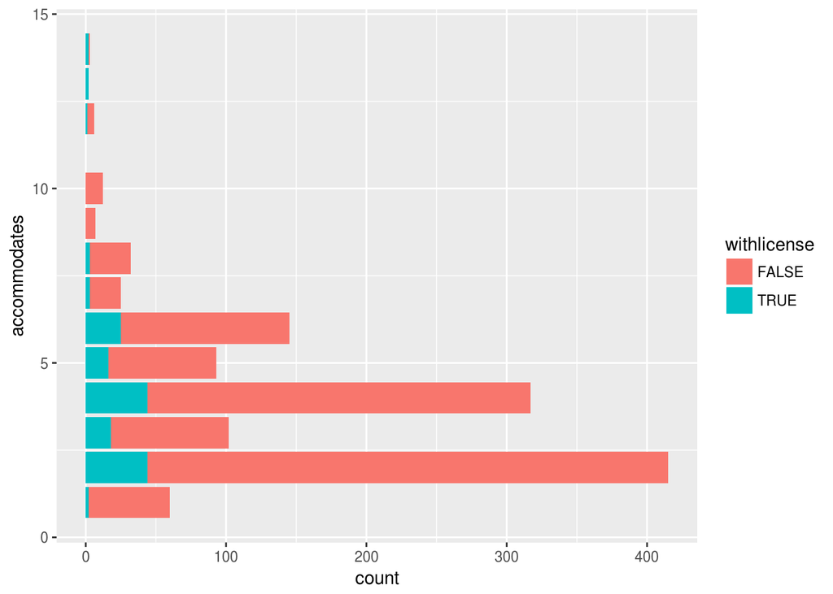

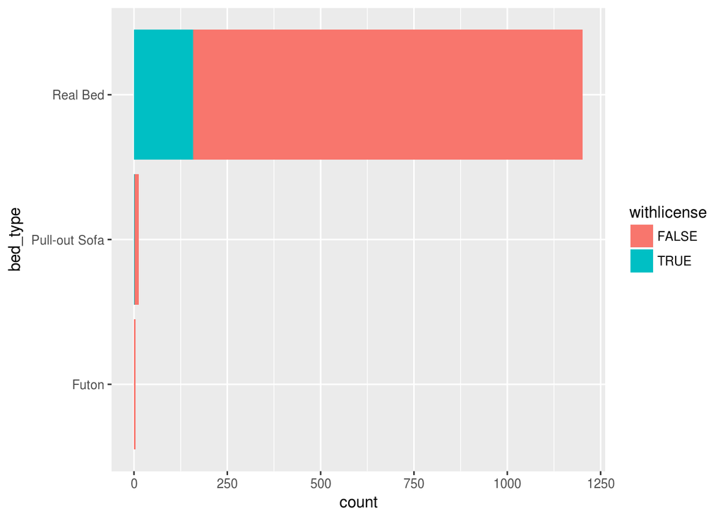

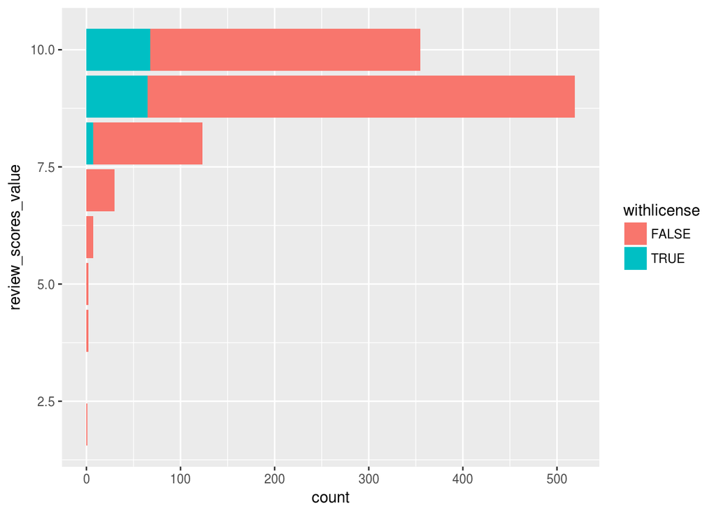

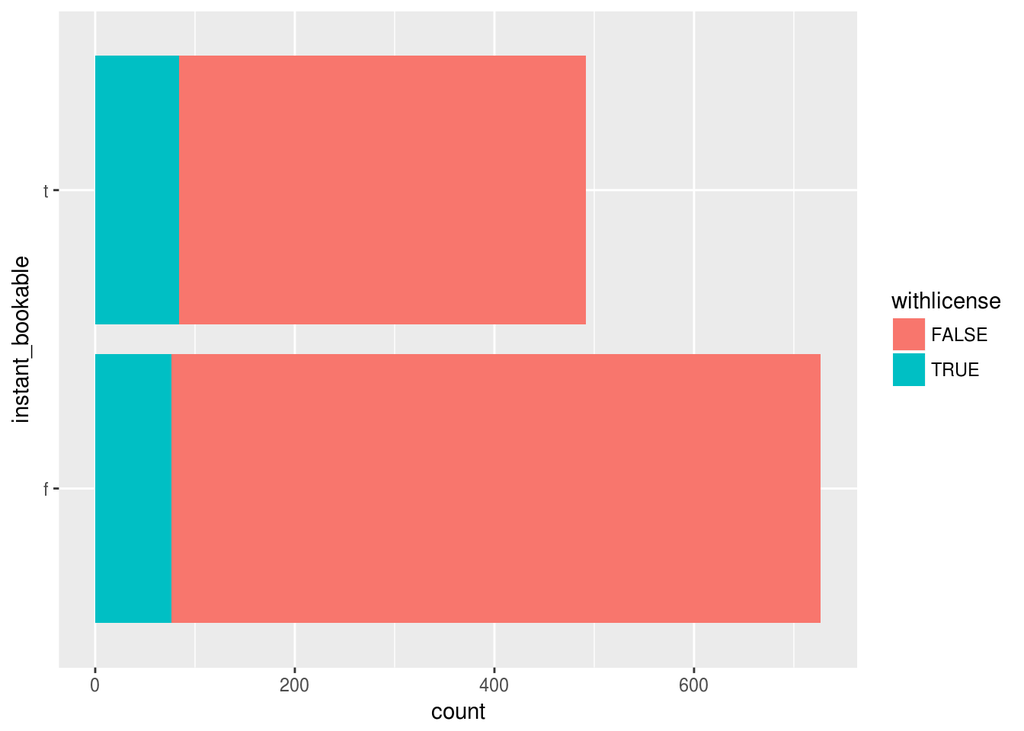

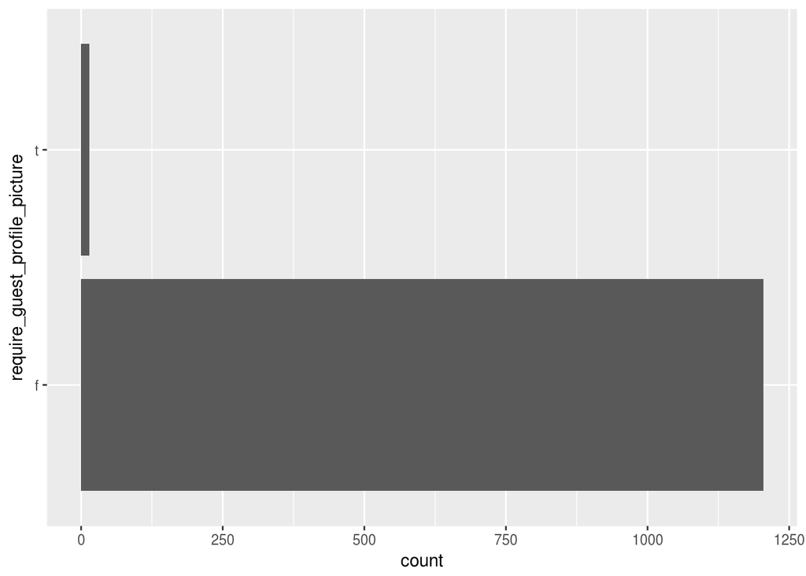

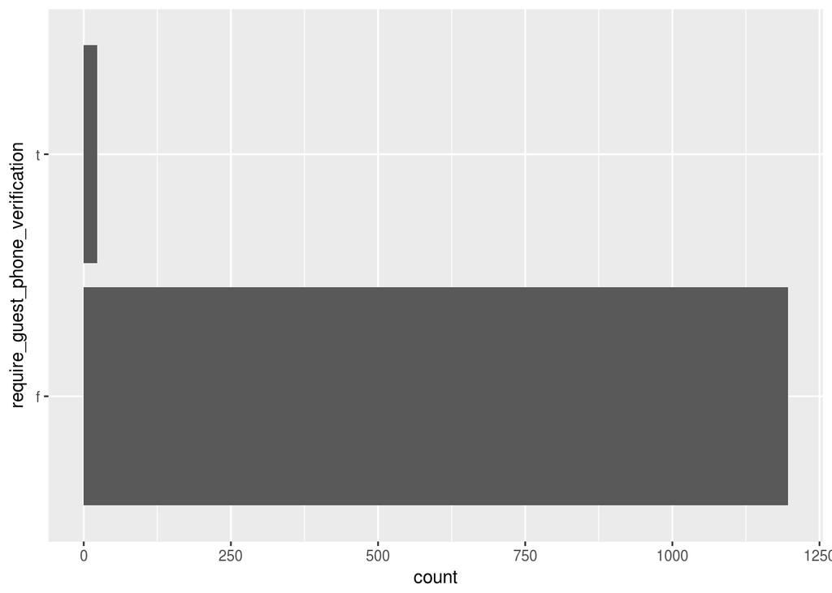

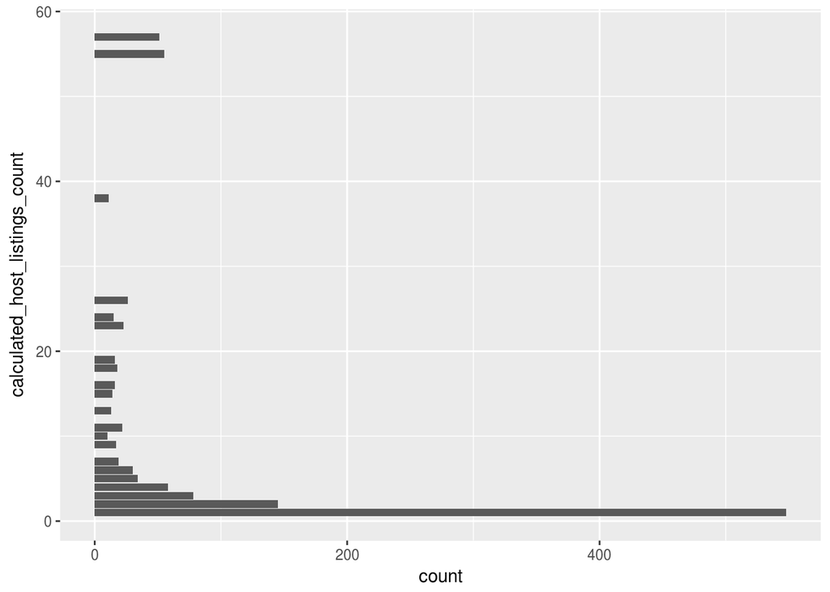

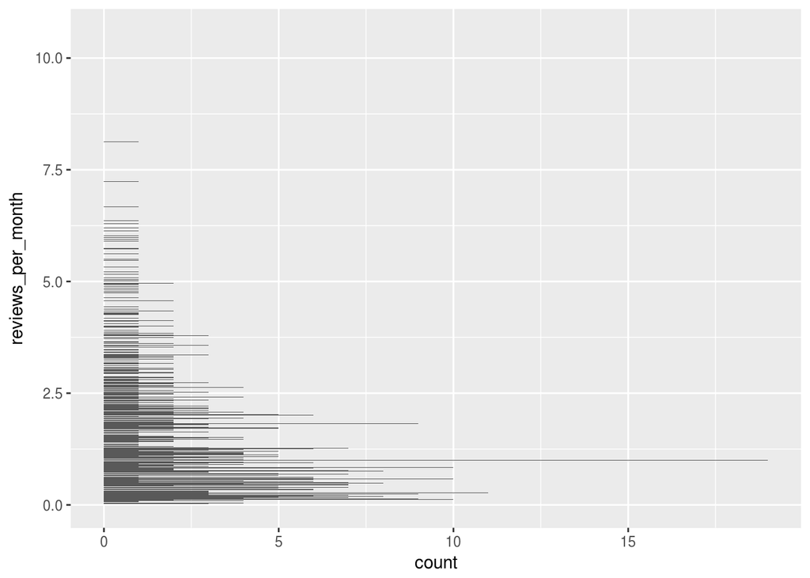

[6 more figures not shown]

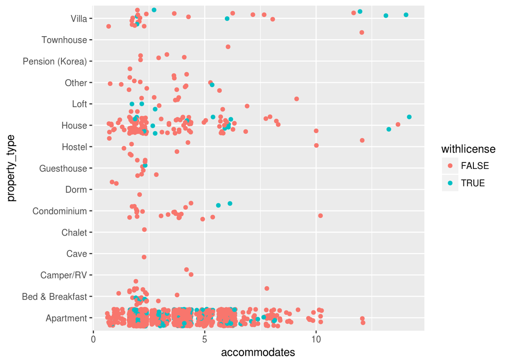

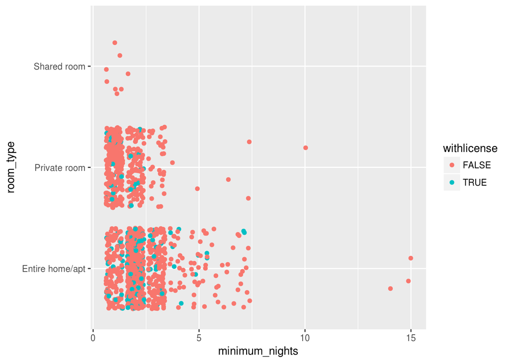

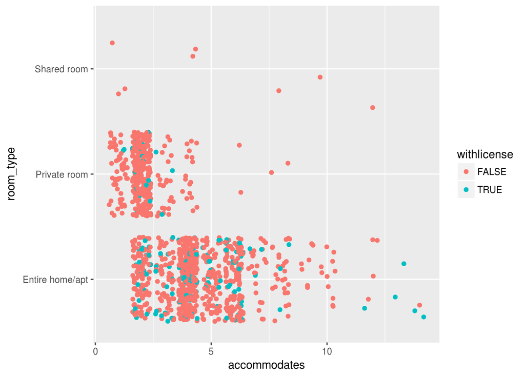